# Analyzing Individual BGG Users

Phil Henrickson

2022-01-02

# **Grimnick’s** BoardGameGeek Collection

This notebook contains a set of analyses for the selected user’s boardgamegeek collection. The bulk of the analysis is focused on building a user-specific predictive model to predict the games that Grimnick is likely to own. This enables to ask questions like, based on the games the user currently owns, what games are a good fit for their collection? What upcoming games are they likely to purchase?

This analysis is based on data from BoardGameGeek that was last updated on **2021-12-20.**

# 1 Collection Overview

We can look at a basic description of the number of games that the user owns, has rated, has previously owned, etc.

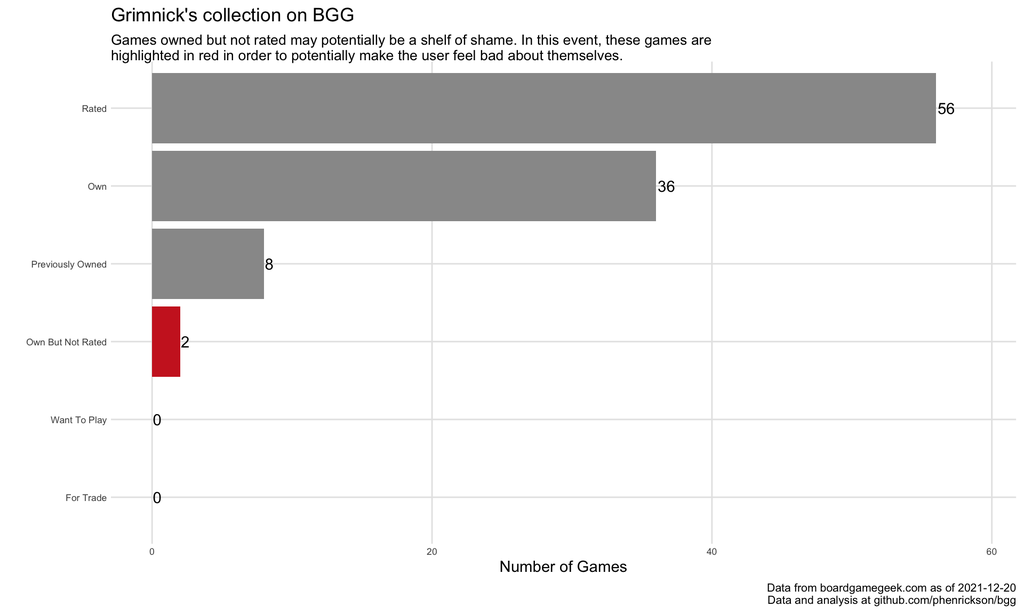

What years has the user owned/rated games from? While we can’t see when a user added or removed a game from their collection, we can look at their collection by the years in which their games were published.

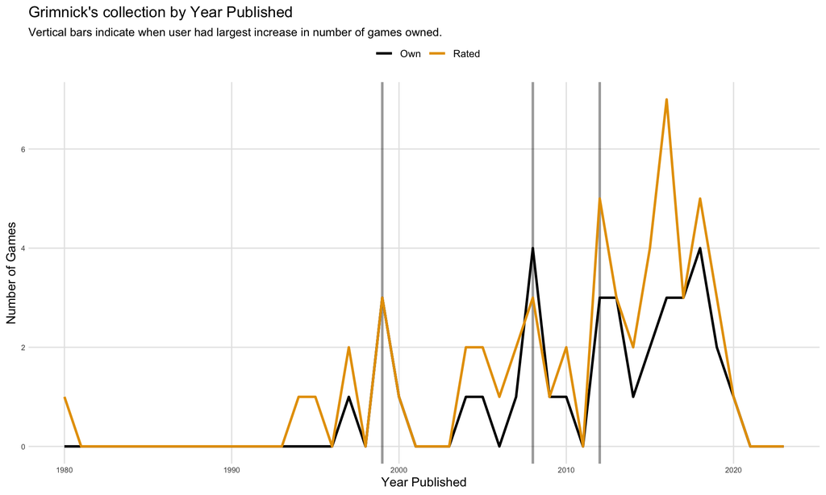

## 1.1 What types of games does Grimnick own?

We can look at the most frequent types of categories, mechanics, designers, and artists that appear in a user’s collection.

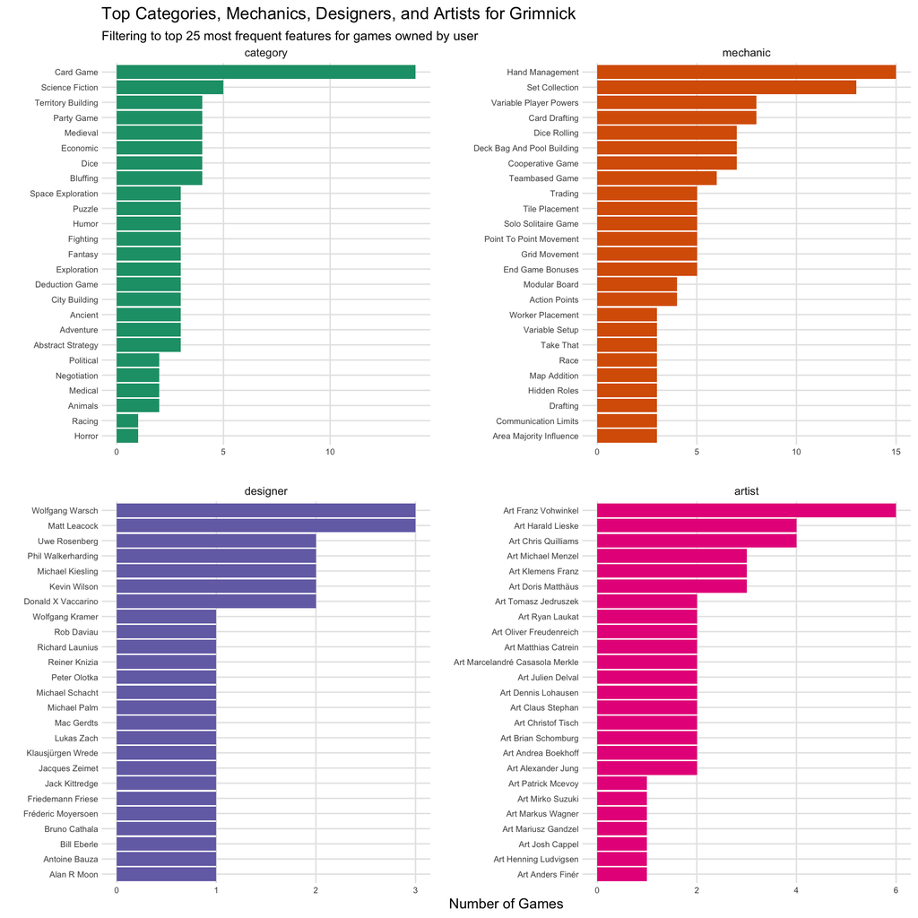

# 2 Modeling **Grimnick’s** Collection

| username | dataset | period | games_owned | games_rated | games_played |
| --- | --- | --- | --- | --- | --- |
| Grimnick | training | published before 2020 | 35 | 55 | 59 |
| Grimnick | test | published 2020 or later | 1 | 1 | 1 |

There are two main (binary) outcomes we will be modeling for the user.

The first, **own** refers to whether the user currently lists a game as owned in their collection. The second, **played** refers to whether the user currently owns, has rated, or previously owned a game. This means the latter will generally have a larger list of games, but may still be a useful category to examine for people who play lots of games without necessarily owning them.

We will train predictive models to learn the probability that the user will own or play individual games based on their features.

## 2.1 Coefficients for Grimnick

We can examine coefficients from the trained modes, which are penalized logistic regressions fit to our two main outcomes. Positive values indicate that a feature increases a user’s probabilility of owning/rating a game, while negative values indicate a feature decreases the probability.

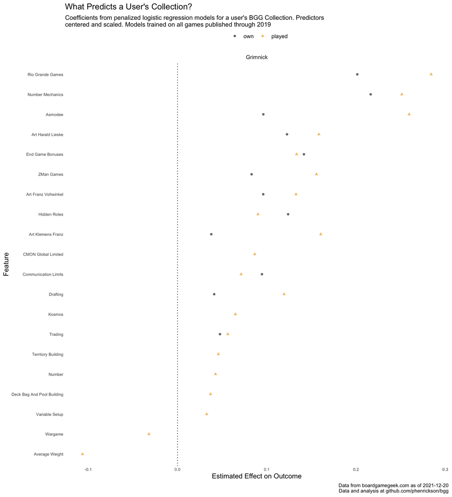

## 2.2 Visualizing Predictors for Grimnick’s Collection

Why did the model identify these features? We can make density plots of the important features for predicting whether the user owned a game. Blue indicates the density for games owned by the user, while grey indicates the density for games not owned by the user.

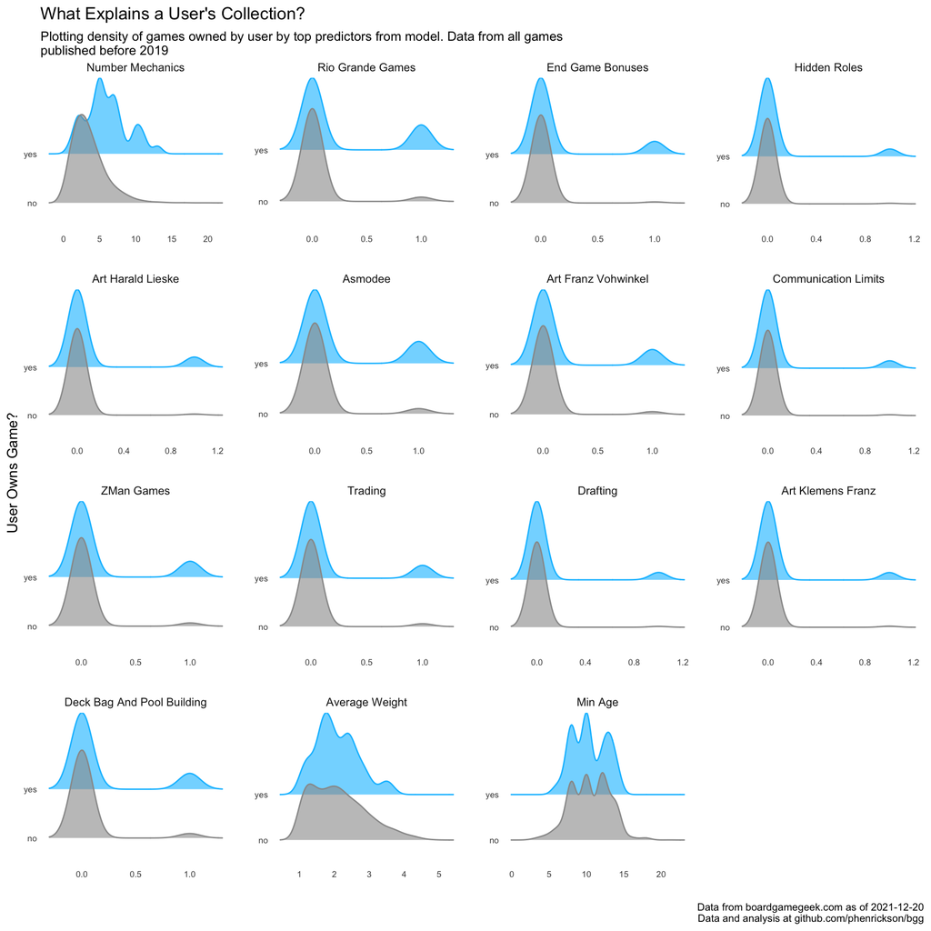

Binary predictors can be difficult to see with this visualization, so we can also directly examine the percentage of games in a user’s collection with a predictor vs the percentage of all games with that predictor.

| username | Feature | % of Games with Feature In_Collection | % of Games with Feature All_Games | Ratio |
| --- | --- | --- | --- | --- |
| Grimnick | Hidden Roles | 8.6% | 0.7% | 12.2 |
| Grimnick | End Game Bonuses | 14.3% | 1.2% | 11.5 |
| Grimnick | Communication Limits | 8.6% | 1.0% | 8.8 |
| Grimnick | Drafting | 8.6% | 1.0% | 8.3 |
| Grimnick | Rio Grande Games | 25.7% | 4.4% | 5.8 |
| Grimnick | ZMan Games | 17.1% | 3.5% | 4.9 |
| Grimnick | Trading | 14.3% | 3.2% | 4.5 |
| Grimnick | Asmodee | 22.9% | 5.3% | 4.3 |
| Grimnick | Deck Bag And Pool Building | 17.1% | 4.8% | 3.5 |
| Grimnick | Prehistoric | 2.9% | 1.0% | 2.8 |
| Grimnick | Puzzle | 8.6% | 3.4% | 2.6 |
| Grimnick | City Building | 8.6% | 4.3% | 2.0 |
| Grimnick | Medieval | 11.4% | 6.3% | 1.8 |
| Grimnick | Negotiation | 5.7% | 3.6% | 1.6 |
| Grimnick | Party Game | 11.4% | 8.5% | 1.3 |
| Grimnick | Deduction Game | 8.6% | 6.4% | 1.3 |
| Grimnick | Racing | 2.9% | 2.8% | 1.0 |
| Grimnick | Horror | 2.9% | 4.0% | 0.7 |
| Grimnick | Realtime | 2.9% | 4.2% | 0.7 |
| Grimnick | Action Dexterity | 2.9% | 4.8% | 0.6 |
| Grimnick | Word Game | 0.0% | 1.8% | 0.0 |
| Grimnick | Trivia | 0.0% | 1.8% | 0.0 |
| Grimnick | Mafia | 0.0% | 0.7% | 0.0 |
| Grimnick | Trains | 0.0% | 2.2% | 0.0 |
| Grimnick | Sports | 0.0% | 2.0% | 0.0 |

# 3 Assess Model’s Performance on Training Set

Before predicting games in upcoming years, we can examine how well the model did and what games it liked in the training set. In this case, we used resampling techniques (cross validation) to ensure that the model had not seen a game before making its predictions.

## 3.1 Separation Plot

An easy way to examine the performance of classification model is to view a separation plot. We plot the predicted probabilities from the model for every game (from resampling) from lowest to highest. We then overlay a blue line for any game that the user does own. A good classifier is one that is able to *separate* the blue (games owned by the user) from the white (games not owned by the user), with most of the blue occurring at the highest probabilities (right side of the chart).

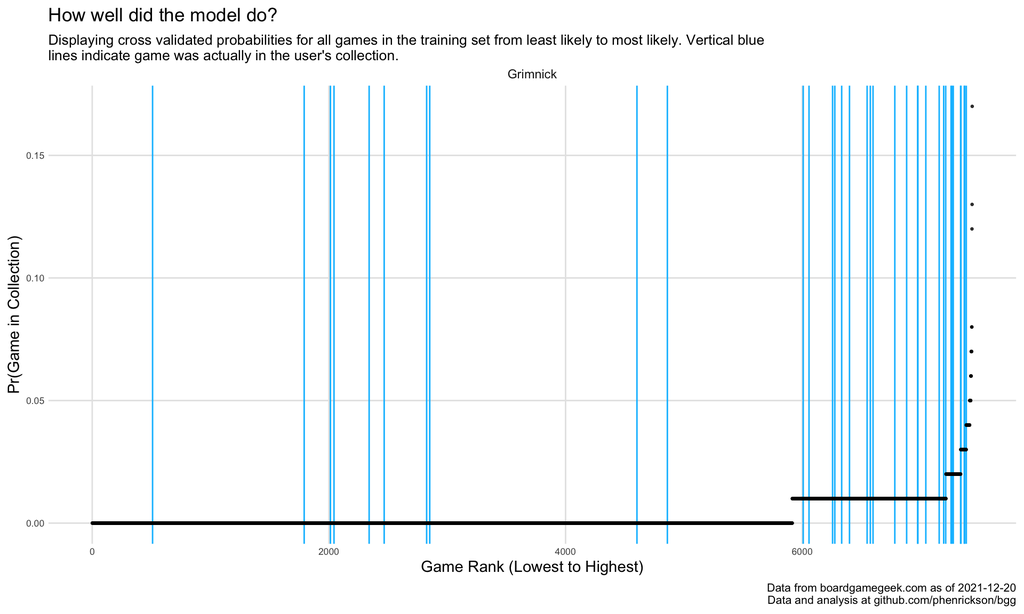

## 3.2 Top Games for **Grimnick** from Training Set

We can display this information in table form, displaying the 100 games with the highest probability of ownership, adding a blue line when the user does own the game.

| username | yearpublished | game_id | name | pred_played | pred_own | actual_played | actual_own |
| --- | --- | --- | --- | --- | --- | --- | --- |
| Grimnick | 2002 | 3076 | Puerto Rico | 0.35 | 0.17 | 0 | 0 |
| Grimnick | 2002 | 4636 | Clans | 0.12 | 0.13 | 0 | 0 |
| Grimnick | 2018 | 205896 | Rising Sun | 0.78 | 0.12 | 0 | 0 |
| Grimnick | 2000 | 478 | Citadels | 0.71 | 0.08 | 0 | 0 |
| Grimnick | 2008 | 37111 | Battlestar Galactica: The Board Game | 0.05 | 0.08 | 0 | 0 |
| Grimnick | 2007 | 27173 | Vikings | 0.15 | 0.07 | 0 | 0 |
| Grimnick | 1995 | 13 | Catan | 0.20 | 0.07 | 1 | 0 |
| Grimnick | 2014 | 156129 | Deception: Murder in Hong Kong | 0.07 | 0.07 | 0 | 0 |
| Grimnick | 2016 | 198454 | When I Dream | 0.12 | 0.07 | 0 | 0 |
| Grimnick | 2014 | 166384 | Spyfall | 0.03 | 0.06 | 0 | 0 |
| Grimnick | 2016 | 205716 | New Angeles | 0.03 | 0.06 | 0 | 0 |
| Grimnick | 2014 | 146652 | Legendary Encounters: An Alien Deck Building Game | 0.04 | 0.06 | 0 | 0 |
| Grimnick | 2000 | 555 | The Princes of Florence | 0.07 | 0.06 | 0 | 0 |
| Grimnick | 2009 | 35503 | Ra: The Dice Game | 0.11 | 0.05 | 0 | 0 |
| Grimnick | 2017 | 174430 | Gloomhaven | 0.18 | 0.05 | 0 | 0 |
| Grimnick | 2015 | 175878 | 504 | 0.09 | 0.05 | 0 | 0 |
| Grimnick | 2015 | 182874 | Grand Austria Hotel | 0.13 | 0.05 | 0 | 0 |
| Grimnick | 2019 | 273477 | Obscurio | 0.01 | 0.05 | 0 | 0 |
| Grimnick | 2010 | 65200 | Asteroyds | 0.12 | 0.05 | 0 | 0 |
| Grimnick | 2018 | 167355 | Nemesis | 0.05 | 0.05 | 0 | 0 |
| Grimnick | 2015 | 178054 | A Study in Emerald (Second Edition) | 0.04 | 0.05 | 0 | 0 |
| Grimnick | 2012 | 120677 | Terra Mystica | 0.11 | 0.05 | 0 | 0 |
| Grimnick | 2012 | 118048 | Targi | 0.12 | 0.04 | 1 | 1 |
| Grimnick | 2010 | 73439 | Troyes | 0.09 | 0.04 | 0 | 0 |
| Grimnick | 2015 | 181687 | The Pursuit of Happiness | 0.10 | 0.04 | 0 | 0 |
| Grimnick | 2007 | 31481 | Galaxy Trucker | 0.07 | 0.04 | 0 | 0 |
| Grimnick | 2019 | 269603 | Minecraft: Builders & Biomes | 0.01 | 0.04 | 0 | 0 |
| Grimnick | 2017 | 220308 | Gaia Project | 0.16 | 0.04 | 0 | 0 |
| Grimnick | 2018 | 247763 | Underwater Cities | 0.08 | 0.04 | 0 | 0 |
| Grimnick | 2011 | 148319 | Tragedy Looper | 0.02 | 0.04 | 0 | 0 |

[output cut: 70 more lines]

We can also more formally assess how well the model did in resampling by looking at the area under the receiver operating characteristic. A perfect model would receive a score of 1, while a model that cannot predict the outcome will default to a score of 0.5. The extent to which something is a *good* score depends on the setting, but generally anything in the .8 to .9 range is very good while the .7 to .8 range is perfectly acceptable.

| username | outcome_type | .metric | .estimator | .estimate |
| --- | --- | --- | --- | --- |
| Grimnick | own | roc_auc | binary | 0.782 |
| Grimnick | played | roc_auc | binary | 0.799 |

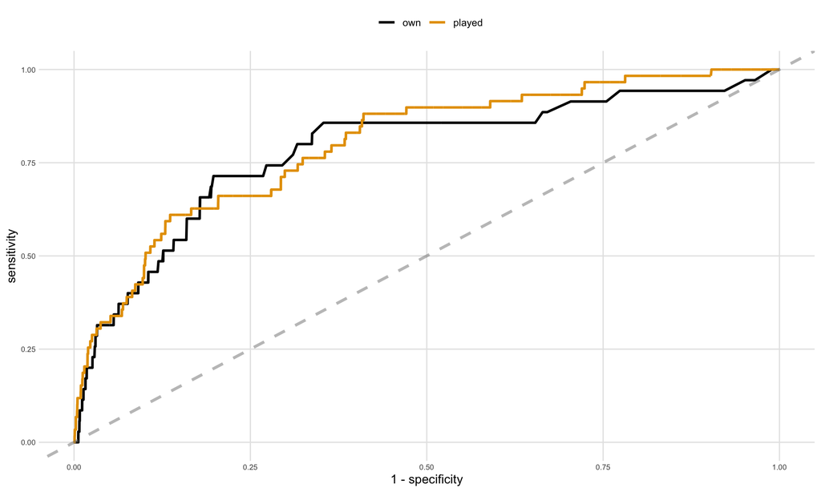

Another way to think about the model performance is to view its lift, or its ability to detect the positive outcomes over that of a null model. High lift indicates the model can much more quickly find all of the positive outcomes (in this case, games owned or played by the user), while a model with no lift is no better than random guessing.

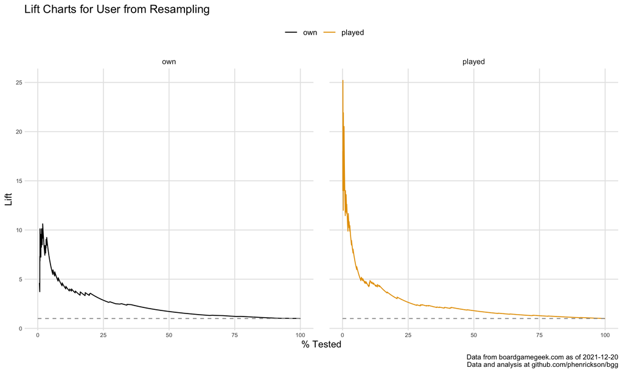

## 3.3 Most and Least Likely Games

What games does the model think Grimnick is **most likely to own** that are **not** in their collection?

| username | yearpublished | game_id | name | pred_own | actual_own |
| --- | --- | --- | --- | --- | --- |
| Grimnick | 2002 | 3076 | Puerto Rico | 0.17 | 0 |
| Grimnick | 2002 | 4636 | Clans | 0.13 | 0 |
| Grimnick | 2018 | 205896 | Rising Sun | 0.12 | 0 |
| Grimnick | 2000 | 478 | Citadels | 0.08 | 0 |
| Grimnick | 2008 | 37111 | Battlestar Galactica: The Board Game | 0.08 | 0 |

What games does the model think Grimnick is **least likely to own** that **are** in their collection?

| username | yearpublished | game_id | name | pred_own | actual_own |
| --- | --- | --- | --- | --- | --- |
| Grimnick | 2015 | 173346 | 7 Wonders Duel | 0 | 1 |
| Grimnick | 2018 | 246192 | Gizmos | 0 | 1 |
| Grimnick | 2017 | 219513 | Bärenpark | 0 | 1 |
| Grimnick | 2018 | 244521 | The Quacks of Quedlinburg | 0 | 1 |
| Grimnick | 2012 | 143884 | Machi Koro | 0 | 1 |

## 3.4 Top Games by Year

Top 25 games most likely to be owned by the user in each year, highlighting in blue the games that the user has owned/played.

| rank | 2011 | 2012 | 2013 | 2014 | 2015 | 2016 | 2017 | 2018 | 2019 |
| --- | --- | --- | --- | --- | --- | --- | --- | --- | --- |
| 1 | Tragedy Looper | Terra Mystica | A Study in Emerald | Deception: Murder in Hong Kong | 504 | When I Dream | Gloomhaven | Rising Sun | Obscurio |
| 2 | Discworld: Ankh-Morpork | Targi | Sushi Go! | Spyfall | Grand Austria Hotel | New Angeles | Gaia Project | Nemesis | Minecraft: Builders & Biomes |
| 3 | Friday | Lords of Waterdeep | Concept | Legendary Encounters: An Alien Deck Building Game | A Study in Emerald (Second Edition) | Agricola (Revised Edition) | Calimala | Underwater Cities | Maracaibo |
| 4 | Pantheon | Il Vecchio | The Ravens of Thri Sahashri | Camel Up | The Pursuit of Happiness | Sushi Go Party! | Paper Tales | Kero | Amul |
| 5 | The Secret of Monte Cristo | One Night Werewolf | Legacy: The Testament of Duke de Crecy | Good Cop Bad Cop | Codenames | Timebomb | Pandemic Legacy: Season 2 | Gingerbread House | It's a Wonderful World |
| 6 | Takenoko | Keyflower | Tajemnicze Domostwo | Templar Intrigue | One Night Ultimate Werewolf: Daybreak | Codenames: Pictures | The Chameleon | Hail Hydra | The Magnificent |
| 7 | A Few Acres of Snow | A Fake Artist Goes to New York | Bomb Squad | One Night Ultimate Werewolf | One Night Ultimate Vampire | Codenames: Deep Undercover | One Night Ultimate Alien | Decrypto | Nanty Narking |
| 8 | Ascension: Return of the Fallen | Tzolk'in: The Mayan Calendar | Carcassonne: South Seas | Castles of Mad King Ludwig | ...and then, we held hands. | Terraforming Mars | Werewords | Pax Emancipation | Old West Empresario |
| 9 | The Castles of Burgundy | Clash of Cultures | Metallum | Five Tribes | I, Spy | 13 Days: The Cuban Missile Crisis | Fog of Love | Werewords Deluxe Edition | Era: Medieval Age |
| 10 | Principato | Kairo | Rivet Wars: Eastern Front | [redacted] | The Bloody Inn | Bohnanza: The Duel | Tortuga 1667 | Newton | Silver & Gold |
| 11 | The Gnomes of Zavandor | Copycat | Piñata | Power Grid Deluxe: Europe/North America | One Night Revolution | Yokohama | Photosynthesis | Coimbra | Subtext |
| 12 | Village | Space Cadets | Cruel Necessity: The English Civil Wars 1640-1653 | Spurs: A Tale in the Old West | RYŪ | Hit Z Road | Azul | Blue Lagoon | Western Empires |
| 13 | Feudalia | Archipelago | Colonialism | Praetor | Tiny Epic Galaxies | Clank!: A Deck-Building Adventure | Pocket Mars | Azul: Stained Glass of Sintra | Chocolate Factory |
| 14 | Gears of War: The Board Game | The Manhattan Project | BioShock Infinite: The Siege of Columbia | Roll for the Galaxy | The Grizzled | Pandemic: Reign of Cthulhu | Codenames: Marvel | Sherlock: Death on the 4th of July | Sierra West |
| 15 | Ora et Labora | Antike Duellum | Pathfinder Adventure Card Game: Rise of the Runelords – Base Set | Dead of Winter: A Crossroads Game | Trambahn | A Feast for Odin | Aristeia! | Sherlock: Last Call | Yōkai |
| 16 | Space Empires: 4X | Pocket Battles: Macedonians vs. Persians | City of Remnants | Heroes of Normandie | Haleakala | Islebound | LYNGK | Sherlock: Paradero Desconocido | Barrage |
| 17 | The Ares Project | Agricola: All Creatures Big and Small | Amerigo | Akrotiri | Castellion | Assembly | Smash Up: What Were We Thinking? | Muse: Awakenings | Pipeline |
| 18 | Fortuna | Le Havre: The Inland Port | Asgard's Chosen | Smash Up: Monster Smash | Sylvion | Insider | Caverna: Cave vs Cave | Human Punishment: Social Deduction 2.0 | Clank!: Legacy – Acquisitions Incorporated |
| 19 | Artus | In Magnificent Style: Pickett's Charge at Gettysburg | Glass Road | Patchwork | Hengist | Power Grid: The Card Game | Codenames: Duet | Western Legends | DANY |
| 20 | Rune Age | Agents of SMERSH | Coal Baron | Fields of Arle | Chaosmos | The Oregon Trail Card Game | The Cousins' War | New Frontiers | Tiny Towns |
| 21 | Alcatraz: The Scapegoat | Star Trek Deck Building Game: The Next Generation – Next Phase | Battle For Souls | Gold Ahoy! | T.I.M.E Stories | Avenue | Triplock | Pandemic: Fall of Rome | Ragusa |
| 22 | Tournay | Star Trek Deck Building Game: The Original Series | Berserk: War of the Realms | Onirim (Second Edition) | Haspelknecht | Pandemic: Iberia | Finished! | Cosmic Encounter: 42nd Anniversary Edition | The King's Dilemma |
| 23 | Mage Knight Board Game | Suburbia | Bruges | Sons of Anarchy: Men of Mayhem | Blood Rage | Scythe | Sidereal Confluence | Too Many Bones: Undertow | Hadara |
| 24 | Eminent Domain | Mice and Mystics | Quantum | Johari | Burgle Bros. | One Deck Dungeon | Mythic Battles: Pantheon | A Song of Ice & Fire: Tabletop Miniatures Game – Stark vs Lannister Starter Set | Crystal Palace |
| 25 | Octopus's Garden | Serenissima (Second Edition) | Prosperity | Deus | My Village | Smash Up: Cease and Desist | First Martians: Adventures on the Red Planet | Duelosaur Island | Carnival of Monsters |

## 3.5 Interactive Predictions from Resampling

Interactive table for predictions from resampling.

|  | username | yearpublished | rank | game_id | name | pred_played | pred_own | actual_played | actual_own |
| --- | --- | --- | --- | --- | --- | --- | --- | --- | --- |
| 1 | Grimnick | 1900 | 1157 | 2785 | Game of Goose | 0.01 | 0.01 | 0 | 0 |
| 2 | Grimnick | 1900 | 1171 | 11670 | The Game of Authors | 0.01 | 0.01 | 0 | 0 |
| 3 | Grimnick | 1900 | 1178 | 10799 | Old Maid | 0.02 | 0.01 | 0 | 0 |
| 4 | Grimnick | 1900 | 1536 | 5546 | Marbles | 0 | 0 | 0 | 0 |
| 5 | Grimnick | 1900 | 1539 | 11901 | Tic-Tac-Toe | 0 | 0 | 0 | 0 |
| 6 | Grimnick | 1900 | 1583 | 188 | Go | 0 | 0 | 0 | 0 |
| 7 | Grimnick | 1900 | 1682 | 171 | Chess | 0 | 0 | 0 | 0 |
| 8 | Grimnick | 1900 | 1688 | 2065 | Shogi | 0 | 0 | 0 | 0 |
| 9 | Grimnick | 1900 | 1690 | 2393 | Xiangqi | 0 | 0 | 0 | 0 |
| 10 | Grimnick | 1900 | 1895 | 26952 | International Checkers | 0 | 0 | 0 | 0 |

[output cut: 7426 more lines]

# 4 Validating the Model on 2020

How well did a model trained on a user’s collection through 2019 perform in predicting games for the user from 2020?

| username | outcome_type | yearpublished | .metric | .estimator | .estimate |
| --- | --- | --- | --- | --- | --- |
| Grimnick | own | 2020 | roc_auc | binary | 0.846 |
| Grimnick | played | 2020 | roc_auc | binary | 0.924 |

Table of top 25 games from 2020, highlighting games that the user owns.

| username | yearpublished | game_id | name | pred_own | pred_played | actual_own | actual_played |
| --- | --- | --- | --- | --- | --- | --- | --- |
| Grimnick | 2020 | 184267 | On Mars | 0.05 | 0.13 | 0 | 0 |
| Grimnick | 2020 | 292333 | Cowboys II: Cowboys & Indians Edition | 0.05 | 0.07 | 0 | 0 |
| Grimnick | 2020 | 308765 | Praga Caput Regni | 0.05 | 0.09 | 0 | 0 |
| Grimnick | 2020 | 256317 | Guild Master | 0.04 | 0.06 | 0 | 0 |
| Grimnick | 2020 | 291457 | Gloomhaven: Jaws of the Lion | 0.04 | 0.08 | 0 | 0 |
| Grimnick | 2020 | 318983 | Faiyum | 0.04 | 0.10 | 0 | 0 |
| Grimnick | 2020 | 323784 | Ghost Letters | 0.04 | 0.03 | 0 | 0 |
| Grimnick | 2020 | 300322 | Hallertau | 0.03 | 0.10 | 0 | 0 |
| Grimnick | 2020 | 227224 | The Red Cathedral | 0.02 | 0.03 | 0 | 0 |
| Grimnick | 2020 | 253506 | Versailles 1919 | 0.02 | 0.02 | 0 | 0 |
| Grimnick | 2020 | 261403 | Inhuman Conditions | 0.02 | 0.02 | 0 | 0 |
| Grimnick | 2020 | 263421 | Enigma: Beyond Code | 0.02 | 0.01 | 0 | 0 |
| Grimnick | 2020 | 277927 | Bites | 0.02 | 0.03 | 0 | 0 |
| Grimnick | 2020 | 291874 | Dwergar | 0.02 | 0.04 | 0 | 0 |
| Grimnick | 2020 | 293889 | Fallout Shelter: The Board Game | 0.02 | 0.02 | 0 | 0 |
| Grimnick | 2020 | 294216 | Musical Chairs | 0.02 | 0.05 | 0 | 0 |
| Grimnick | 2020 | 296151 | Viscounts of the West Kingdom | 0.02 | 0.02 | 0 | 0 |
| Grimnick | 2020 | 296483 | The Great Race | 0.02 | 0.02 | 0 | 0 |
| Grimnick | 2020 | 297204 | Traintopia | 0.02 | 0.06 | 0 | 0 |
| Grimnick | 2020 | 299960 | Alma Mater | 0.02 | 0.04 | 0 | 0 |
| Grimnick | 2020 | 301767 | Mysterium Park | 0.02 | 0.03 | 0 | 0 |
| Grimnick | 2020 | 302310 | Nanaki | 0.02 | 0.02 | 0 | 0 |
| Grimnick | 2020 | 302840 | Carcata | 0.02 | 0.04 | 0 | 0 |
| Grimnick | 2020 | 307844 | Atheneum: Mystic Library | 0.02 | 0.05 | 0 | 0 |
| Grimnick | 2020 | 307997 | Insider Black | 0.02 | 0.02 | 0 | 0 |

# 5 Predicting Upcoming Games (2020 and On) for **Grimnick**

Examine the top games for the test set.

| username | yearpublished | game_id | name | rank | own | played |
| --- | --- | --- | --- | --- | --- | --- |
| Grimnick | 2020 | 308765 | Praga Caput Regni | 1 | 0.05 | 0.09 |
| Grimnick | 2020 | 292333 | Cowboys II: Cowboys & Indians Edition | 2 | 0.05 | 0.07 |
| Grimnick | 2020 | 184267 | On Mars | 3 | 0.05 | 0.13 |
| Grimnick | 2020 | 318983 | Faiyum | 4 | 0.04 | 0.10 |
| Grimnick | 2020 | 323784 | Ghost Letters | 5 | 0.04 | 0.03 |
| Grimnick | 2020 | 256317 | Guild Master | 6 | 0.04 | 0.06 |
| Grimnick | 2020 | 291457 | Gloomhaven: Jaws of the Lion | 7 | 0.04 | 0.08 |
| Grimnick | 2020 | 300322 | Hallertau | 8 | 0.03 | 0.10 |
| Grimnick | 2020 | 301767 | Mysterium Park | 9 | 0.02 | 0.03 |
| Grimnick | 2020 | 296483 | The Great Race | 10 | 0.02 | 0.02 |
| Grimnick | 2020 | 277927 | Bites | 11 | 0.02 | 0.03 |
| Grimnick | 2020 | 293889 | Fallout Shelter: The Board Game | 12 | 0.02 | 0.02 |
| Grimnick | 2020 | 263421 | Enigma: Beyond Code | 13 | 0.02 | 0.01 |
| Grimnick | 2020 | 307997 | Insider Black | 14 | 0.02 | 0.02 |
| Grimnick | 2020 | 302310 | Nanaki | 15 | 0.02 | 0.02 |
| Grimnick | 2020 | 313698 | Monster Expedition | 16 | 0.02 | 0.02 |
| Grimnick | 2020 | 320819 | Dinner in Paris | 17 | 0.02 | 0.03 |
| Grimnick | 2020 | 261403 | Inhuman Conditions | 18 | 0.02 | 0.02 |
| Grimnick | 2020 | 312762 | The Joker | 19 | 0.02 | 0.02 |
| Grimnick | 2020 | 291874 | Dwergar | 20 | 0.02 | 0.04 |
| Grimnick | 2020 | 317985 | Beyond the Sun | 21 | 0.02 | 0.04 |
| Grimnick | 2020 | 227224 | The Red Cathedral | 22 | 0.02 | 0.03 |
| Grimnick | 2020 | 253506 | Versailles 1919 | 23 | 0.02 | 0.02 |
| Grimnick | 2020 | 315954 | Hunt A Killer: Death at the Dive Bar | 24 | 0.02 | 0.02 |
| Grimnick | 2020 | 297204 | Traintopia | 25 | 0.02 | 0.06 |
| Grimnick | 2021 | 298102 | Roll Camera!: The Filmmaking Board Game | 1 | 0.07 | 0.10 |
| Grimnick | 2021 | 310873 | Carnegie | 2 | 0.04 | 0.04 |
| Grimnick | 2021 | 291847 | Mantis Falls | 3 | 0.04 | 0.09 |
| Grimnick | 2021 | 343905 | Boonlake | 4 | 0.04 | 0.16 |
| Grimnick | 2021 | 319263 | One Card Dungeon | 5 | 0.03 | 0.03 |
| Grimnick | 2021 | 319999 | Dungeon Decorators | 6 | 0.03 | 0.08 |
| Grimnick | 2021 | 340466 | Unfathomable | 7 | 0.03 | 0.04 |
| Grimnick | 2021 | 341048 | Free Ride | 8 | 0.03 | 0.08 |
| Grimnick | 2021 | 344408 | Full Throttle! | 9 | 0.02 | 0.07 |
| Grimnick | 2021 | 318182 | Imperium: Legends | 10 | 0.02 | 0.02 |
| Grimnick | 2021 | 206757 | Glory: A Game of Knights | 11 | 0.02 | 0.02 |
| Grimnick | 2021 | 329465 | Red Rising | 12 | 0.02 | 0.02 |
| Grimnick | 2021 | 337262 | Fangs | 13 | 0.02 | 0.02 |
| Grimnick | 2021 | 309408 | Arcana Rising | 14 | 0.02 | 0.04 |
| Grimnick | 2021 | 315624 | World Changers | 15 | 0.02 | 0.04 |
| Grimnick | 2021 | 282776 | Tumble Town | 16 | 0.02 | 0.02 |
| Grimnick | 2021 | 320446 | Corduba 27 a.C. | 17 | 0.02 | 0.02 |
| Grimnick | 2021 | 313262 | Shamans | 18 | 0.02 | 0.02 |
| Grimnick | 2021 | 318184 | Imperium: Classics | 19 | 0.02 | 0.03 |
| Grimnick | 2021 | 330608 | Cryo | 20 | 0.02 | 0.03 |
| Grimnick | 2021 | 308989 | Bristol 1350 | 21 | 0.02 | 0.02 |
| Grimnick | 2021 | 297531 | Watch | 22 | 0.02 | 0.04 |
| Grimnick | 2021 | 283387 | Rocketmen | 23 | 0.02 | 0.02 |
| Grimnick | 2021 | 342942 | Ark Nova | 24 | 0.02 | 0.03 |
| Grimnick | 2021 | 310100 | Nemesis: Lockdown | 25 | 0.02 | 0.02 |
| Grimnick | 2022 | 317511 | Tindaya | 1 | 0.04 | 0.05 |
| Grimnick | 2022 | 295770 | Frosthaven | 2 | 0.03 | 0.03 |
| Grimnick | 2022 | 283137 | Human Punishment: The Beginning | 3 | 0.03 | 0.03 |
| Grimnick | 2022 | 331106 | The Witcher: Old World | 4 | 0.02 | 0.06 |
| Grimnick | 2022 | 324090 | Scarface 1920 | 5 | 0.02 | 0.02 |
| Grimnick | 2022 | 326945 | Castles of Mad King Ludwig: Collector's Edition | 6 | 0.02 | 0.02 |
| Grimnick | 2022 | 335427 | Wild: Serengeti | 7 | 0.02 | 0.02 |
| Grimnick | 2022 | 240980 | Blood on the Clocktower | 8 | 0.02 | 0.01 |
| Grimnick | 2022 | 316624 | Stationfall | 9 | 0.02 | 0.01 |
| Grimnick | 2022 | 320718 | Hidden Leaders | 10 | 0.02 | 0.02 |
| Grimnick | 2022 | 305096 | Endless Winter: Paleoamericans | 11 | 0.02 | 0.03 |
| Grimnick | 2022 | 319807 | Shogun no Katana | 12 | 0.02 | 0.02 |
| Grimnick | 2022 | 280726 | Legacies | 13 | 0.02 | 0.02 |
| Grimnick | 2022 | 304051 | Creature Comforts | 14 | 0.02 | 0.02 |
| Grimnick | 2022 | 271601 | Feed the Kraken | 15 | 0.02 | 0.02 |
| Grimnick | 2022 | 252315 | The Everrain | 16 | 0.01 | 0.01 |
| Grimnick | 2022 | 277025 | Vampire: The Masquerade – CHAPTERS | 17 | 0.01 | 0.01 |
| Grimnick | 2022 | 299594 | Megapulse | 18 | 0.01 | 0.01 |
| Grimnick | 2022 | 316915 | U.S.S. Freedom | 19 | 0.01 | 0.01 |
| Grimnick | 2022 | 330950 | Age of Galaxy | 20 | 0.01 | 0.01 |
| Grimnick | 2022 | 348463 | ECO: Coral Reef | 21 | 0.01 | 0.01 |
| Grimnick | 2022 | 274471 | Malhya: Lands of Legends | 22 | 0.01 | 0.01 |
| Grimnick | 2022 | 294880 | Chai: Tea for 2 | 23 | 0.01 | 0.01 |
| Grimnick | 2022 | 281647 | Stellaris: Infinite Legacy | 24 | 0.01 | 0.01 |
| Grimnick | 2022 | 281258 | Sub Terra II: Inferno's Edge | 25 | 0.01 | 0.01 |

## 5.1 Interactive Table for Upcoming Games 2020 and On

|  | username | yearpublished | game_id | name | rank | own | played |
| --- | --- | --- | --- | --- | --- | --- | --- |
| 1 | Grimnick | 2021 | 298102 | Roll Camera!: The Filmmaking Board Game | 1 | 0.07 | 0.1 |
| 2 | Grimnick | 2020 | 308765 | Praga Caput Regni | 2 | 0.05 | 0.09 |
| 3 | Grimnick | 2020 | 292333 | Cowboys II: Cowboys &amp; Indians Edition | 3 | 0.05 | 0.07 |
| 4 | Grimnick | 2020 | 184267 | On Mars | 4 | 0.05 | 0.13 |
| 5 | Grimnick | 2021 | 310873 | Carnegie | 5 | 0.04 | 0.04 |
| 6 | Grimnick | 2022 | 317511 | Tindaya | 6 | 0.04 | 0.05 |
| 7 | Grimnick | 2021 | 291847 | Mantis Falls | 7 | 0.04 | 0.09 |
| 8 | Grimnick | 2021 | 343905 | Boonlake | 8 | 0.04 | 0.16 |
| 9 | Grimnick | 2020 | 318983 | Faiyum | 9 | 0.04 | 0.1 |
| 10 | Grimnick | 2020 | 323784 | Ghost Letters | 10 | 0.04 | 0.03 |

[output cut: 1627 more lines]